# Prediction of credit card defaulters with machine learning techniques

### Section D10. Student Number - 501009454

## Initial Dataset Analysis

```r
library(ggplot2)
library(mlbench)
library(DataExplorer)
library(dplyr)
library(imbalance)
library(caret)
library(MLeval)
library(ROCR)
```

The very first and important step of the machine learning process while performing any data analysis is to prepare data for its proper future interpretation. Clean data can notably increase the accuracy of any model. Usually we start that in R with reading a dataset file using a command ‘read.csv’. We want to have the headers as in original file and do not have factor values. For this ‘header’ argument is set to ‘True’ and ‘stringAsFactors’ – to ‘False’.

```r
projectData = read.csv("D:\\Study\\CIND820 - Big Data Analytics Project\\Project\\Initial Analysis\\credit_card.csv", header = TRUE,  sep = ",", stringsAsFactors = FALSE)
```

Now we can start investigating our data. We would need to learn the shape, size, type and general layout of the data that we have. A command ‘head’ shows us the first six rows and gives us understanding how the dataset looks like.

```r
head(projectData)
```

```
##   ID LIMIT_BAL SEX EDUCATION MARRIAGE AGE PAY_0 PAY_2 PAY_3 PAY_4 PAY_5 PAY_6
## 1  1     20000   2         2        1  24     2     2    -1    -1    -2    -2
## 2  2    120000   2         2        2  26    -1     2     0     0     0     2
## 3  3     90000   2         2        2  34     0     0     0     0     0     0
## 4  4     50000   2         2        1  37     0     0     0     0     0     0
## 5  5     50000   1         2        1  57    -1     0    -1     0     0     0
## 6  6     50000   1         1        2  37     0     0     0     0     0     0
##   BILL_AMT1 BILL_AMT2 BILL_AMT3 BILL_AMT4 BILL_AMT5 BILL_AMT6 PAY_AMT1 PAY_AMT2
## 1      3913      3102       689         0         0         0        0      689
## 2      2682      1725      2682      3272      3455      3261        0     1000
## 3     29239     14027     13559     14331     14948     15549     1518     1500
## 4     46990     48233     49291     28314     28959     29547     2000     2019
## 5      8617      5670     35835     20940     19146     19131     2000    36681
## 6     64400     57069     57608     19394     19619     20024     2500     1815
##   PAY_AMT3 PAY_AMT4 PAY_AMT5 PAY_AMT6 default.payment.next.month
## 1        0        0        0        0                          1
## 2     1000     1000        0     2000                          1
## 3     1000     1000     1000     5000                          0
## 4     1200     1100     1069     1000                          0
## 5    10000     9000      689      679                          0
## 6      657     1000     1000      800                          0
```

There are twenty-five columns describing attributes of each credit card customer in terms of his/her sex, education, age, payment history, bill amount and status of payments in different months (see table 1 from Literature Review). To avoid any complications further, our target variable ‘default.payment.next.month’ is going to be renamed to simpler name ‘DEFAULT_PAYMENT’ using the following code:

```r
colnames(projectData)[colnames(projectData)=="default.payment.next.month"] <- "DEFAULT_PAYMENT"
head(projectData)
```

```
##   ID LIMIT_BAL SEX EDUCATION MARRIAGE AGE PAY_0 PAY_2 PAY_3 PAY_4 PAY_5 PAY_6
## 1  1     20000   2         2        1  24     2     2    -1    -1    -2    -2
## 2  2    120000   2         2        2  26    -1     2     0     0     0     2
## 3  3     90000   2         2        2  34     0     0     0     0     0     0
## 4  4     50000   2         2        1  37     0     0     0     0     0     0
## 5  5     50000   1         2        1  57    -1     0    -1     0     0     0
## 6  6     50000   1         1        2  37     0     0     0     0     0     0
##   BILL_AMT1 BILL_AMT2 BILL_AMT3 BILL_AMT4 BILL_AMT5 BILL_AMT6 PAY_AMT1 PAY_AMT2
## 1      3913      3102       689         0         0         0        0      689
## 2      2682      1725      2682      3272      3455      3261        0     1000
## 3     29239     14027     13559     14331     14948     15549     1518     1500
## 4     46990     48233     49291     28314     28959     29547     2000     2019
## 5      8617      5670     35835     20940     19146     19131     2000    36681
## 6     64400     57069     57608     19394     19619     20024     2500     1815
##   PAY_AMT3 PAY_AMT4 PAY_AMT5 PAY_AMT6 DEFAULT_PAYMENT
## 1        0        0        0        0               1
## 2     1000     1000        0     2000               1
## 3     1000     1000     1000     5000               0
## 4     1200     1100     1069     1000               0
## 5    10000     9000      689      679               0
## 6      657     1000     1000      800               0
```

Then with ‘dim’ function we can easily check that the given data set has 30000 records in it. Using a standard command ‘str’ we may find out of what type is each variable

```r
dim(projectData)
```

```
## [1] 30000    25
```

```r
str(projectData)
```

```
## 'data.frame':    30000 obs. of  25 variables:
##  $ ID             : int  1 2 3 4 5 6 7 8 9 10 ...
##  $ LIMIT_BAL      : num  20000 120000 90000 50000 50000 50000 500000 100000 140000 20000 ...
##  $ SEX            : int  2 2 2 2 1 1 1 2 2 1 ...
##  $ EDUCATION      : int  2 2 2 2 2 1 1 2 3 3 ...
##  $ MARRIAGE       : int  1 2 2 1 1 2 2 2 1 2 ...
##  $ AGE            : int  24 26 34 37 57 37 29 23 28 35 ...
##  $ PAY_0          : int  2 -1 0 0 -1 0 0 0 0 -2 ...
##  $ PAY_2          : int  2 2 0 0 0 0 0 -1 0 -2 ...
##  $ PAY_3          : int  -1 0 0 0 -1 0 0 -1 2 -2 ...
##  $ PAY_4          : int  -1 0 0 0 0 0 0 0 0 -2 ...
##  $ PAY_5          : int  -2 0 0 0 0 0 0 0 0 -1 ...
##  $ PAY_6          : int  -2 2 0 0 0 0 0 -1 0 -1 ...
##  $ BILL_AMT1      : num  3913 2682 29239 46990 8617 ...
##  $ BILL_AMT2      : num  3102 1725 14027 48233 5670 ...
##  $ BILL_AMT3      : num  689 2682 13559 49291 35835 ...
##  $ BILL_AMT4      : num  0 3272 14331 28314 20940 ...
##  $ BILL_AMT5      : num  0 3455 14948 28959 19146 ...
##  $ BILL_AMT6      : num  0 3261 15549 29547 19131 ...
##  $ PAY_AMT1       : num  0 0 1518 2000 2000 ...
##  $ PAY_AMT2       : num  689 1000 1500 2019 36681 ...
##  $ PAY_AMT3       : num  0 1000 1000 1200 10000 657 38000 0 432 0 ...
##  $ PAY_AMT4       : num  0 1000 1000 1100 9000 ...
##  $ PAY_AMT5       : num  0 0 1000 1069 689 ...
##  $ PAY_AMT6       : num  0 2000 5000 1000 679 ...
##  $ DEFAULT_PAYMENT: int  1 1 0 0 0 0 0 0 0 0 ...
```

Since we have a classification problem in this project, there is a necessity to know the proportion of instances that belong to each class label. This is important because it may highlight an imbalance in the data, that if severe may need to be addressed with rebalancing techniques. The code below creates a useful table showing the number of instances that belong to each class as well as the percentage that this represents from the entire dataset:

```r
y <- projectData$DEFAULT_PAYMENT
cbind(freq=table(y), percentage=prop.table(table(y))*100)
```

```
##    freq percentage
## 0 23364      77.88
## 1  6636      22.12
```

As it is seen, the given dataset has rather imbalanced data where class ‘0’ is presented triple as much as class ‘1’. Due to this we will need to address this issue with specific methods.

## Exploratory Data Analysis

Applying the summary() function to a data frame will return the summary showing main descriptive statistics (min, 25 percentile, median, mean, 75 percentile, max) for all numeric values. It also indicates, if applicable, the number of missing values for an attribute (marked NA). In this case there no missing values at all.

```r
summary(projectData)
```

```
##        ID          LIMIT_BAL            SEX          EDUCATION
##  Min.   :    1   Min.   :  10000   Min.   :1.000   Min.   :0.000
##  1st Qu.: 7501   1st Qu.:  50000   1st Qu.:1.000   1st Qu.:1.000
##  Median :15000   Median : 140000   Median :2.000   Median :2.000
##  Mean   :15000   Mean   : 167484   Mean   :1.604   Mean   :1.853
##  3rd Qu.:22500   3rd Qu.: 240000   3rd Qu.:2.000   3rd Qu.:2.000
##  Max.   :30000   Max.   :1000000   Max.   :2.000   Max.   :6.000
##     MARRIAGE          AGE            PAY_0             PAY_2
##  Min.   :0.000   Min.   :21.00   Min.   :-2.0000   Min.   :-2.0000
##  1st Qu.:1.000   1st Qu.:28.00   1st Qu.:-1.0000   1st Qu.:-1.0000
##  Median :2.000   Median :34.00   Median : 0.0000   Median : 0.0000
##  Mean   :1.552   Mean   :35.49   Mean   :-0.0167   Mean   :-0.1338
##  3rd Qu.:2.000   3rd Qu.:41.00   3rd Qu.: 0.0000   3rd Qu.: 0.0000
##  Max.   :3.000   Max.   :79.00   Max.   : 8.0000   Max.   : 8.0000
##      PAY_3             PAY_4             PAY_5             PAY_6
##  Min.   :-2.0000   Min.   :-2.0000   Min.   :-2.0000   Min.   :-2.0000
##  1st Qu.:-1.0000   1st Qu.:-1.0000   1st Qu.:-1.0000   1st Qu.:-1.0000
##  Median : 0.0000   Median : 0.0000   Median : 0.0000   Median : 0.0000
##  Mean   :-0.1662   Mean   :-0.2207   Mean   :-0.2662   Mean   :-0.2911
##  3rd Qu.: 0.0000   3rd Qu.: 0.0000   3rd Qu.: 0.0000   3rd Qu.: 0.0000
##  Max.   : 8.0000   Max.   : 8.0000   Max.   : 8.0000   Max.   : 8.0000
##    BILL_AMT1         BILL_AMT2        BILL_AMT3         BILL_AMT4
##  Min.   :-165580   Min.   :-69777   Min.   :-157264   Min.   :-170000
##  1st Qu.:   3559   1st Qu.:  2985   1st Qu.:   2666   1st Qu.:   2327
##  Median :  22382   Median : 21200   Median :  20089   Median :  19052
##  Mean   :  51223   Mean   : 49179   Mean   :  47013   Mean   :  43263
##  3rd Qu.:  67091   3rd Qu.: 64006   3rd Qu.:  60165   3rd Qu.:  54506
##  Max.   : 964511   Max.   :983931   Max.   :1664089   Max.   : 891586
##    BILL_AMT5        BILL_AMT6          PAY_AMT1         PAY_AMT2
##  Min.   :-81334   Min.   :-339603   Min.   :     0   Min.   :      0
##  1st Qu.:  1763   1st Qu.:   1256   1st Qu.:  1000   1st Qu.:    833
##  Median : 18105   Median :  17071   Median :  2100   Median :   2009
##  Mean   : 40311   Mean   :  38872   Mean   :  5664   Mean   :   5921
##  3rd Qu.: 50191   3rd Qu.:  49198   3rd Qu.:  5006   3rd Qu.:   5000
##  Max.   :927171   Max.   : 961664   Max.   :873552   Max.   :1684259
##     PAY_AMT3         PAY_AMT4         PAY_AMT5           PAY_AMT6
##  Min.   :     0   Min.   :     0   Min.   :     0.0   Min.   :     0.0
##  1st Qu.:   390   1st Qu.:   296   1st Qu.:   252.5   1st Qu.:   117.8
##  Median :  1800   Median :  1500   Median :  1500.0   Median :  1500.0
##  Mean   :  5226   Mean   :  4826   Mean   :  4799.4   Mean   :  5215.5
##  3rd Qu.:  4505   3rd Qu.:  4013   3rd Qu.:  4031.5   3rd Qu.:  4000.0
##  Max.   :896040   Max.   :621000   Max.   :426529.0   Max.   :528666.0
##  DEFAULT_PAYMENT
##  Min.   :0.0000
##  1st Qu.:0.0000
##  Median :0.0000
##  Mean   :0.2212
##  3rd Qu.:0.0000
##  Max.   :1.0000
```

Comparing details of data description from table 1 and the results of summary() function, it is seen that two attributes, Education and Marriage, have categories either not included in the dataset description or are meaningless.

From the data description received in table 1 we can see that the Education varible has the following categories: 1=graduate school, 2=university, 3=high school, 4=others, 5=unknown, 6=unknown. In addition, we can observe that this attribute holds 0 number as its value, which is not described in the dataset. We may assume that these 0 values along with 5 and 6 can be categorized under value 4 (other).  
A similar situation is for Marriage variable which holds values like 1=married, 2=single, 3 =others. Since the category 0 hasn’t been defined anywhere, we will include it in the ‘others’ category marked as 3.

Find distribution of Education and Mariage variables with not described categories in data description. Assigning those to meaningful ones

```r
projectData %>% count(EDUCATION, sort = FALSE)
```

```
##   EDUCATION     n
## 1         0    14
## 2         1 10585
## 3         2 14030
## 4         3  4917
## 5         4   123
## 6         5   280
## 7         6    51
```

```r
projectData %>% count(MARRIAGE, sort = FALSE)
```

```
##   MARRIAGE     n
## 1        0    54
## 2        1 13659
## 3        2 15964
## 4        3   323
```

```r
projectData$EDUCATION[projectData$EDUCATION == 0] <- 4
projectData$EDUCATION[projectData$EDUCATION == 5] <- 4
projectData$EDUCATION[projectData$EDUCATION == 6] <- 4

projectData$MARRIAGE[projectData$MARRIAGE == 0] <- 3

projectData %>% count(EDUCATION, sort = FALSE)
```

```
##   EDUCATION     n
## 1         1 10585
## 2         2 14030
## 3         3  4917
## 4         4   468
```

```r
projectData %>% count(MARRIAGE, sort = FALSE)
```

```
##   MARRIAGE     n
## 1        1 13659
## 2        2 15964
## 3        3   377
```

Another important aspect is to explore how the attributes related between each other. For this purpose, the correlation of each pair of numeric attributes will be considered.

```r
correlations <- cor(projectData[,2:25])
print(correlations)
```

```
##                   LIMIT_BAL           SEX    EDUCATION     MARRIAGE         AGE
## LIMIT_BAL        1.00000000  0.0247552351 -0.231087535 -0.111012193  0.14471280
## SEX              0.02475524  1.0000000000  0.013627120 -0.028521804 -0.09087365
## EDUCATION       -0.23108754  0.0136271197  1.000000000 -0.136796941  0.18243430
## MARRIAGE        -0.11101219 -0.0285218038 -0.136796941  1.000000000 -0.41200144
## AGE              0.14471280 -0.0908736465  0.182434297 -0.412001437  1.00000000
## PAY_0           -0.27121433 -0.0576428789  0.112592779  0.018556670 -0.03944738
## PAY_2           -0.29638210 -0.0707710032  0.129703364  0.023620250 -0.05014778
## PAY_3           -0.28612295 -0.0660960564  0.122425201  0.032398549 -0.05304844
## PAY_4           -0.26746001 -0.0601732384  0.116530581  0.031831258 -0.04972167
## PAY_5           -0.24941139 -0.0550638850  0.104088344  0.034377176 -0.05382598
## PAY_6           -0.23519540 -0.0440077882  0.088986192  0.033167707 -0.04877343
## BILL_AMT1        0.28542986 -0.0336418696  0.016597237 -0.027832486  0.05623853
## BILL_AMT2        0.27831436 -0.0311834722  0.011979938 -0.025294286  0.05428307
## BILL_AMT3        0.28323578 -0.0245633117  0.006713832 -0.029082220  0.05370971
## BILL_AMT4        0.29398762 -0.0218796791 -0.006130773 -0.027274078  0.05135309
## BILL_AMT5        0.29556234 -0.0170051802 -0.012438556 -0.029269557  0.04934505
## BILL_AMT6        0.29038895 -0.0167331263 -0.012646400 -0.025065589  0.04761268
## PAY_AMT1         0.19523592 -0.0002424546 -0.041088050 -0.004652635  0.02614668
## PAY_AMT2         0.17840795 -0.0013909097 -0.032793022 -0.009512564  0.02178489
## PAY_AMT3         0.21016675 -0.0085966249 -0.044293209 -0.004249736  0.02924735
## PAY_AMT4         0.20324241 -0.0022289715 -0.040949062 -0.013969985  0.02137901
## PAY_AMT5         0.21720243 -0.0016671618 -0.045138449 -0.003019324  0.02284997
## PAY_AMT6         0.21959537 -0.0027660223 -0.044061042 -0.008382574  0.01947815
## DEFAULT_PAYMENT -0.15351988 -0.0399605777  0.033842230 -0.027574706  0.01388983
##                       PAY_0       PAY_2        PAY_3        PAY_4        PAY_5
## LIMIT_BAL       -0.27121433 -0.29638210 -0.286122954 -0.267460010 -0.249411395
## SEX             -0.05764288 -0.07077100 -0.066096056 -0.060173238 -0.055063885
## EDUCATION        0.11259278  0.12970336  0.122425201  0.116530581  0.104088344
## MARRIAGE         0.01855667  0.02362025  0.032398549  0.031831258  0.034377176
## AGE             -0.03944738 -0.05014778 -0.053048437 -0.049721674 -0.053825976
## PAY_0            1.00000000  0.67216438  0.574245093  0.538840627  0.509426064
## PAY_2            0.67216438  1.00000000  0.766551683  0.662067131  0.622780245
## PAY_3            0.57424509  0.76655168  1.000000000  0.777358873  0.686774511
## PAY_4            0.53884063  0.66206713  0.777358873  1.000000000  0.819835311
## PAY_5            0.50942606  0.62278025  0.686774511  0.819835311  1.000000000
## PAY_6            0.47455309  0.57550086  0.632683593  0.716449482  0.816900160
## BILL_AMT1        0.18706843  0.23488653  0.208472889  0.202812069  0.206683964
## BILL_AMT2        0.18985911  0.23525694  0.237294534  0.225816316  0.226913267
## BILL_AMT3        0.17978528  0.22414586  0.227494327  0.244983138  0.243334681
```

[output cut: 95 more lines]

```
## PAY_5               0.204148914
## PAY_6               0.186866362
## BILL_AMT1          -0.019644197
## BILL_AMT2          -0.014193218
## BILL_AMT3          -0.014075518
## BILL_AMT4          -0.010156496
## BILL_AMT5          -0.006760464
## BILL_AMT6          -0.005372315
## PAY_AMT1           -0.072929488
## PAY_AMT2           -0.058578707
## PAY_AMT3           -0.056250351
## PAY_AMT4           -0.056827401
## PAY_AMT5           -0.055123516
## PAY_AMT6           -0.053183340
## DEFAULT_PAYMENT     1.000000000
```

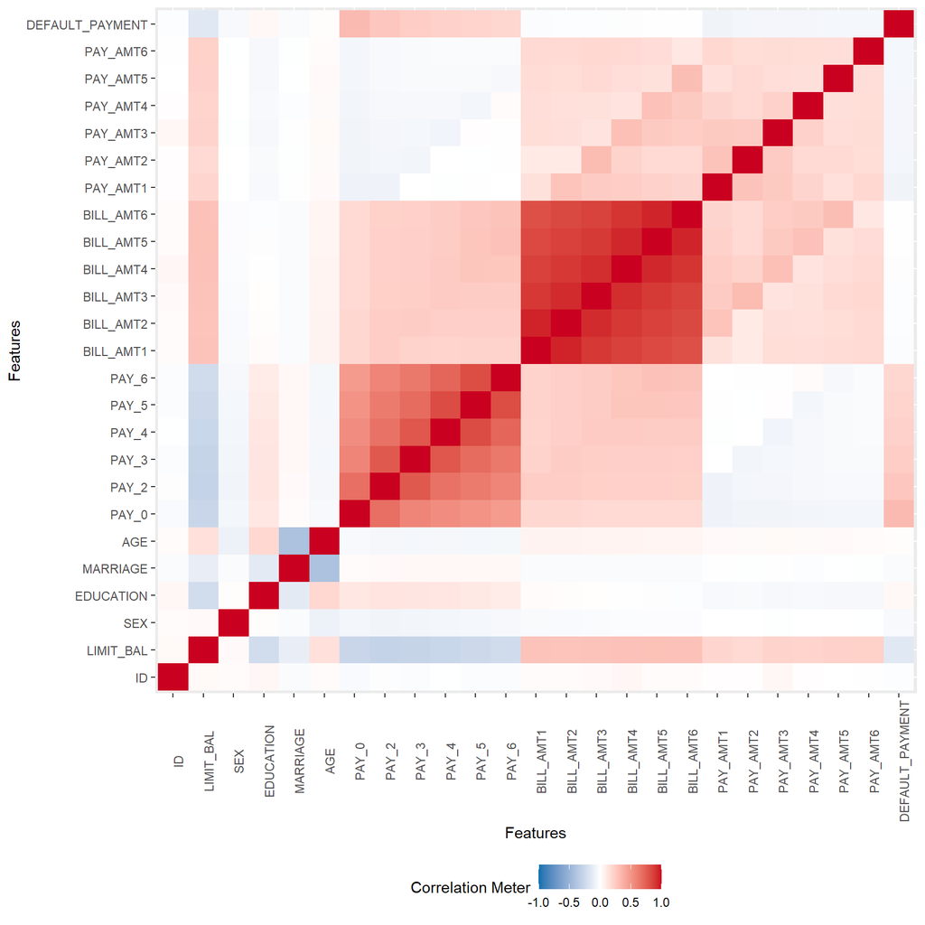

```r
plot_correlation(na.omit(projectData), maxcat = 5L)
```

From this heat map it is seen that particular variables like BILL_AMT1, BILL_AMT2, BILL_AMT3, BILL_AMT4, BILL_AMT5, BILL_AMT6 have a very weak correlation with a class attribute and thus have no impact on a final outcome. Due to this we will not include them in machine learning models.

Next we create a histogram for each attribute and thus performing a univariate analysis of them:

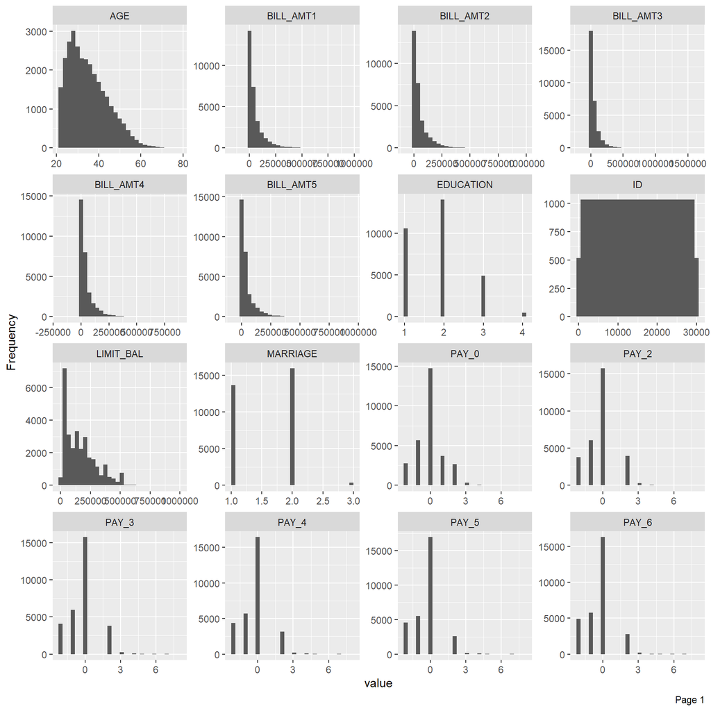

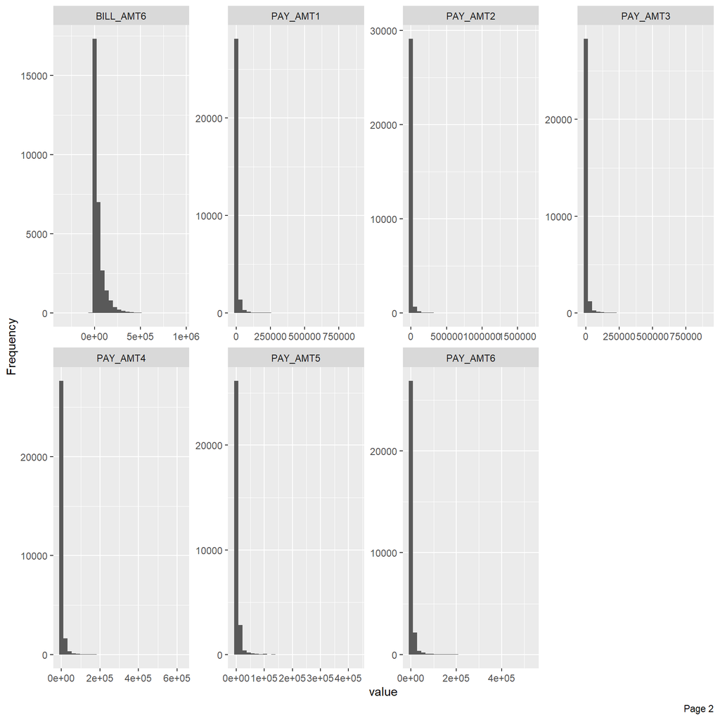

```r
plot_histogram(projectData)
```

The above graphs show that all PAY variables are skewed to the right. Otherwise there are no specific dependencies to highlight.

## Pre-Processing and Feature Selection

Next step is to prepare dataset for modelling. As it was mentioned above BILL_AMT1, BILL_AMT2, BILL_AMT3, BILL_AMT4, BILL_AMT5, BILL_AMT6 attributes have no impact on a class variable and should be deleted from it. That is done with the following code

```r
modelData <- select(projectData, !c('ID', 'BILL_AMT1','BILL_AMT2', 'BILL_AMT3','BILL_AMT4','BILL_AMT5','BILL_AMT6'))
```

Plot a new heat map of correlations after removing attributes from the dataset

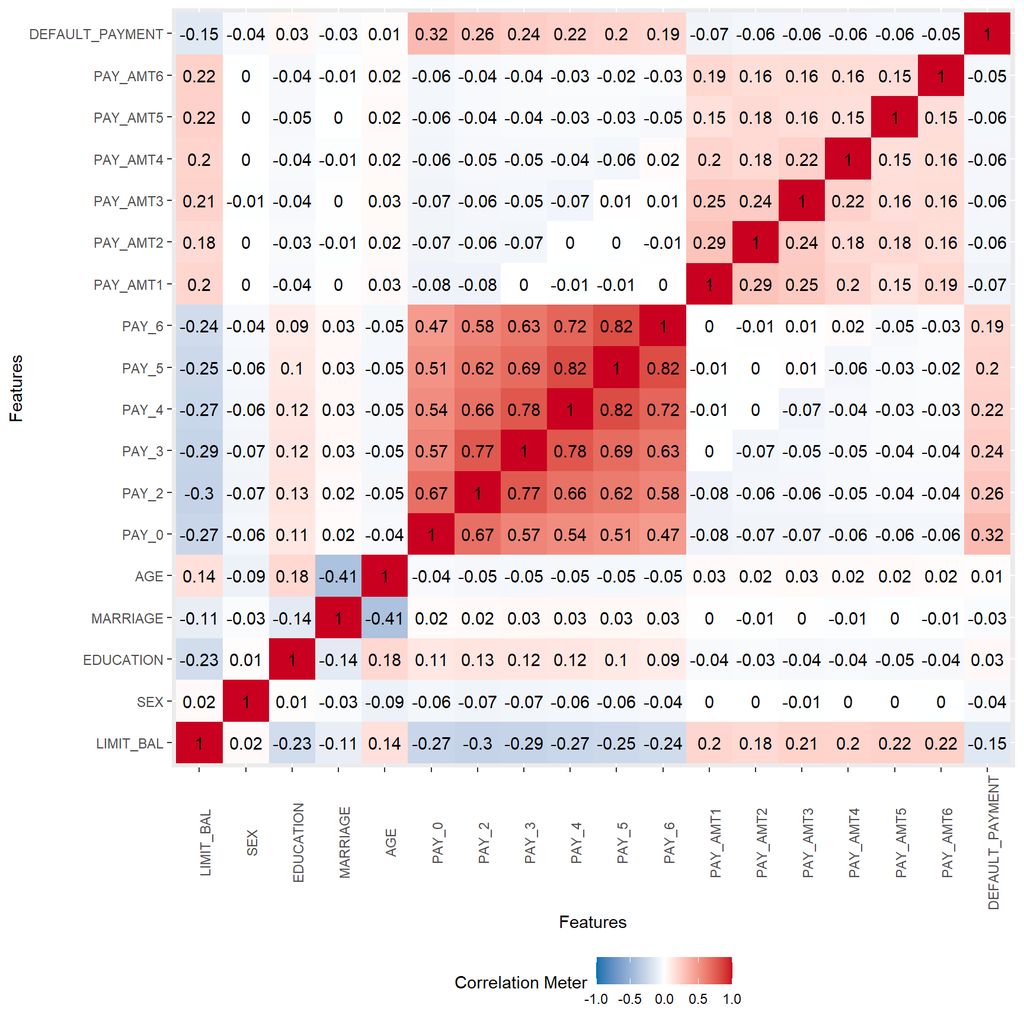

```r
plot_correlation(na.omit(modelData), maxcat = 5L)
```

It is seen that even after removing specific attributes, all others have not so high correlation with the class variable.

Further we need to deal with class imbalance. For this reason, a CRAN package ‘Imbalance’ is installed. Specifically, a majority weighted minority oversampling technique (MWMOTE) for imbalance dataset will be used. It is a modification for SMOTE technique which overcomes some of the problems of the SMOTE technique when there are noisy instances, in which case SMOTE would generate more noisy instances out of them. Oversampling of the dataset with new instances of class variable ‘1’ using MWMOTE technique is done using the folowing code:

```r
newSamples <- mwmote(modelData, numInstances = 10000, classAttr = "DEFAULT_PAYMENT")
summary(newSamples)
```

```
##    LIMIT_BAL           SEX          EDUCATION        MARRIAGE
##  Min.   : 10000   Min.   :1.000   Min.   :1.000   Min.   :1.000
##  1st Qu.: 78454   1st Qu.:1.000   1st Qu.:1.161   1st Qu.:1.054
##  Median :154717   Median :1.000   Median :1.789   Median :1.564
##  Mean   :178193   Mean   :1.335   Mean   :1.752   Mean   :1.540
##  3rd Qu.:261599   3rd Qu.:2.000   3rd Qu.:2.000   3rd Qu.:2.000
##  Max.   :500000   Max.   :2.000   Max.   :3.928   Max.   :3.000
##       AGE            PAY_0             PAY_2             PAY_3
##  Min.   :21.00   Min.   :-2.0000   Min.   :-2.0000   Min.   :-2.0000
##  1st Qu.:30.00   1st Qu.: 0.0000   1st Qu.:-1.0000   1st Qu.:-1.0000
##  Median :35.00   Median : 0.0000   Median :-0.5000   Median :-1.0000
##  Mean   :35.41   Mean   : 0.2246   Mean   :-0.4667   Mean   :-0.6076
##  3rd Qu.:40.00   3rd Qu.: 1.0000   3rd Qu.: 0.0000   3rd Qu.: 0.0000
##  Max.   :70.00   Max.   : 7.0000   Max.   : 6.0000   Max.   : 7.0000
##      PAY_4             PAY_5             PAY_6            PAY_AMT1
##  Min.   :-2.0000   Min.   :-2.0000   Min.   :-2.0000   Min.   :    0.0
##  1st Qu.:-2.0000   1st Qu.:-2.0000   1st Qu.:-2.0000   1st Qu.:    0.0
##  Median :-1.0000   Median :-1.0000   Median :-1.0000   Median :  198.9
##  Mean   :-0.6668   Mean   :-0.7198   Mean   :-0.7617   Mean   :  812.2
##  3rd Qu.: 0.0000   3rd Qu.: 0.0000   3rd Qu.: 0.0000   3rd Qu.: 1053.5
##  Max.   : 7.0000   Max.   : 7.0000   Max.   : 7.0000   Max.   :28309.3
##     PAY_AMT2          PAY_AMT3           PAY_AMT4           PAY_AMT5
##  Min.   :    0.0   Min.   :    0.00   Min.   :    0.00   Min.   :    0.00
##  1st Qu.:    0.0   1st Qu.:    0.00   1st Qu.:    0.00   1st Qu.:    0.00
##  Median :  127.1   Median :   76.38   Median :   66.41   Median :   64.37
##  Mean   :  688.4   Mean   :  585.19   Mean   :  518.16   Mean   :  532.74
##  3rd Qu.:  895.5   3rd Qu.:  650.02   3rd Qu.:  567.36   3rd Qu.:  591.51
##  Max.   :58508.9   Max.   :34922.68   Max.   :29285.01   Max.   :19305.94
##     PAY_AMT6        DEFAULT_PAYMENT
##  Min.   :    0.00   Min.   :1
##  1st Qu.:    0.00   1st Qu.:1
##  Median :   33.94   Median :1
##  Mean   :  497.55   Mean   :1
##  3rd Qu.:  550.89   3rd Qu.:1
##  Max.   :36353.96   Max.   :1
```

After creating new artificial records as a separate data frame, we use function ‘rbind’ to merge two datasets

```r
newData<-rbind(modelData, newSamples)
```

Then we shuffle it in order not to have only the records of the same outcome class in each fold of the future k-fold cross validation modelling.

```r
set.seed(7)
rows <- sample(nrow(newData))
newDataShuffled <- newData[rows, ]

# Transform class variable from numeric to factor

newDataShuffled$DEFAULT_PAYMENT<-factor(newDataShuffled$DEFAULT_PAYMENT,
                                        labels = c("PayInTime", "Default"))
```

Another correlation heat map is created to see how new instances in a dataset affected dependencies between each other.

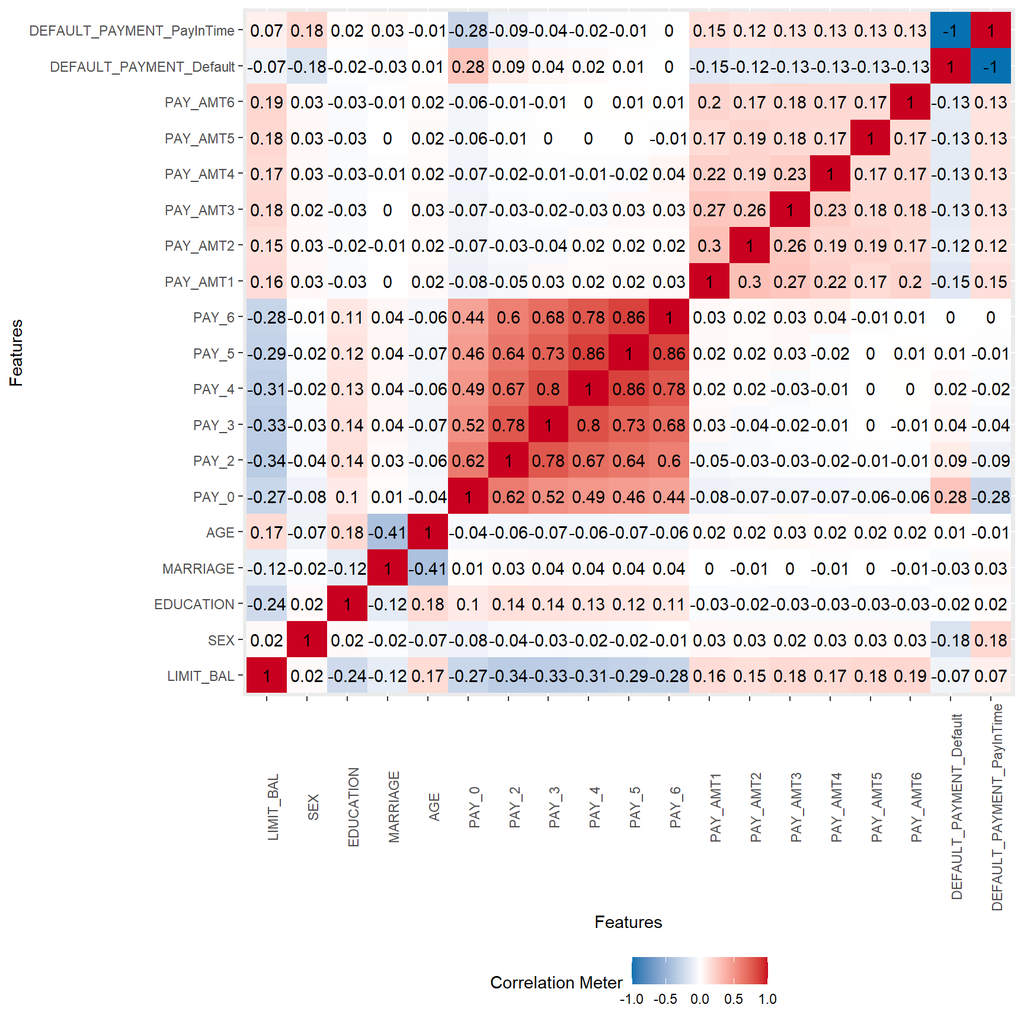

```r
plot_correlation(na.omit(newDataShuffled), maxcat = 5L)
```

It is vividly seen that the values for PAY variables decreased and PAY_AMT increased a little bit in comparison with previous heat map. Nevertheless, we assume that this change is not critical and will not biased the model itself very much.

Then we check again in what proportion the records with different class values are presented in a resulting dataset

```r
z <- newData$DEFAULT_PAYMENT
cbind(freq=table(z), percentage=prop.table(table(z))*100)
```

```
##    freq percentage
## 0 23364      58.41
## 1 16636      41.59
```

There is a ratio of 58.41% to 41.59% of instances that belong to class ‘0’ and class ‘1’ respectively. Due to this we assume that our dataset is balanced now and we can proceed to the machine learning modelling.

## Model Development

First of all we split our dataset into training one and validation one with a proportion 70% and 30% repspectively.

```r
set.seed(5)
train_index <- sample(1:nrow(newDataShuffled), 0.7 * nrow(newDataShuffled))
train.set <- newDataShuffled[train_index,]
test.set  <- newDataShuffled[-train_index,]
```

We will use a ‘caret’ package for development of models and we start from defining a trControl argument. The method is set to cross-validation with K equal to 10, classProbs - to TRUE. It is required to return probability of outcome. In this case it is ‘default’ or ‘not’. And summaryFunction is set to return outcome as a set of binary classification results.

```r
trainControl <- trainControl(method = "cv", number = 10, classProbs= TRUE,
                              summaryFunction=twoClassSummary, savePredictions = TRUE)
```

Further we are going to develop four models using two machine learning classification algorithms particulary Random Forest and Naive Bayes. Two of them will be generated without pre-processing the dataset, other two will be created with data standardization. After developing we print out their performance metrics, plot the fitted results and the importance of variables.

First the models without pre-processing are being developed. As a method in train() function we set ‘rf’ for the Random Forest and ‘nb’ for the Naive Bayes algorithms, metric is set to ‘ROC’ so that the output data is suitable for generating an ROC curve

```r
set.seed(777) # setting seed to generate a reproducible random sampling

#Random Forest model

timeStartRF <- proc.time()

modelRF <- train(DEFAULT_PAYMENT ~., data = train.set, method = "rf",
                 metric = "ROC", type = "Classification", trControl = trainControl)

proc.time() - timeStartRF
```

```
##    user  system elapsed
## 1305.83   21.94 1351.65
```

```r
# Print model performance metrics along with other details

print(modelRF)    # prints the model information
```

```
## Random Forest
##
## 28000 samples
##    17 predictor
##     2 classes: 'PayInTime', 'Default'
##
## No pre-processing
## Resampling: Cross-Validated (10 fold)
## Summary of sample sizes: 25200, 25200, 25200, 25200, 25200, 25200, ...
## Resampling results across tuning parameters:
##
##   mtry  ROC        Sens       Spec
##    2    0.8948124  0.9065664  0.7412077
##    9    0.8938423  0.9153332  0.7404370
##   17    0.8905874  0.9123903  0.7354749
##
## ROC was used to select the optimal model using the largest value.
## The final value used for the model was mtry = 2.
```

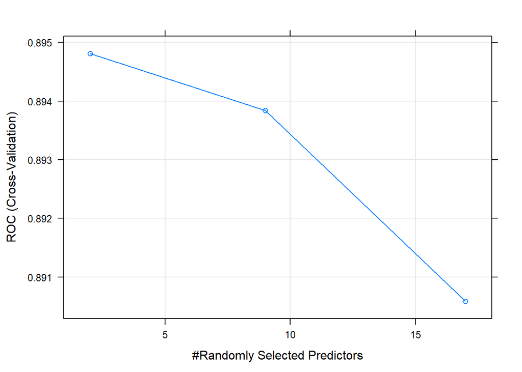

```r
plot(modelRF)     # plots the fitted results. The best AUC is achieved with 2 random predictors
```

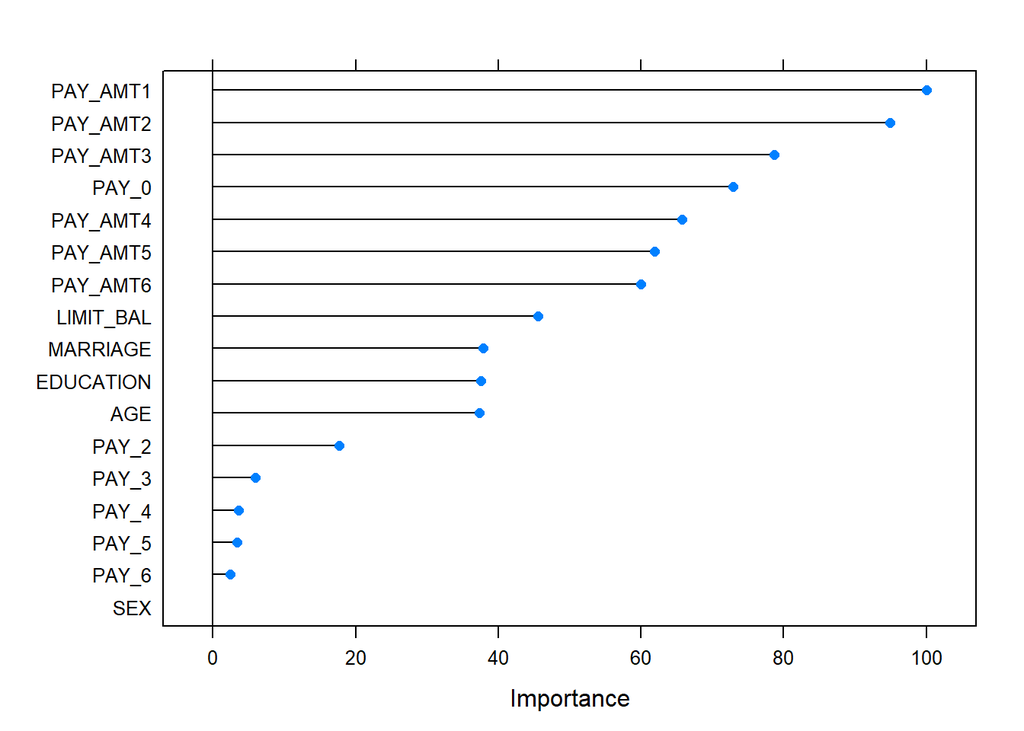

```r
plot(varImp(modelRF))   # returns variable importance
```

```r
# Naive Bayes model

timeStartNB <- proc.time()

modelNB <- train(DEFAULT_PAYMENT ~., data = train.set, method = "nb",
                 metric = "ROC", type = "Classification", trControl = trainControl)

proc.time() - timeStartNB
```

```
##    user  system elapsed
##  148.49    0.36  155.41
```

```r
# Print model performance metrics along with other details

print(modelNB)    # prints the model information
```

```
## Naive Bayes
##
## 28000 samples
##    17 predictor
##     2 classes: 'PayInTime', 'Default'
##
## No pre-processing
## Resampling: Cross-Validated (10 fold)
## Summary of sample sizes: 25200, 25200, 25200, 25200, 25200, 25200, ...
## Resampling results across tuning parameters:
##
##   usekernel  ROC        Sens       Spec
##   FALSE      0.7499040  0.2061185  0.9635563
##    TRUE      0.8280877  0.6385257  0.8201733
##
## Tuning parameter 'fL' was held constant at a value of 0
## Tuning
##  parameter 'adjust' was held constant at a value of 1
## ROC was used to select the optimal model using the largest value.
## The final values used for the model were fL = 0, usekernel = TRUE and adjust
##  = 1.
```

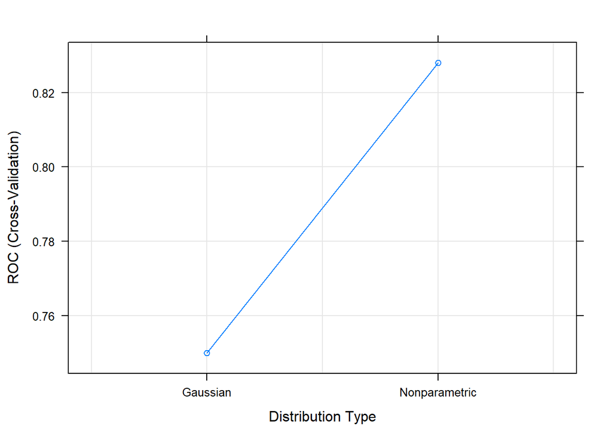

```r
plot(modelNB)     # plots the fitted results.
```

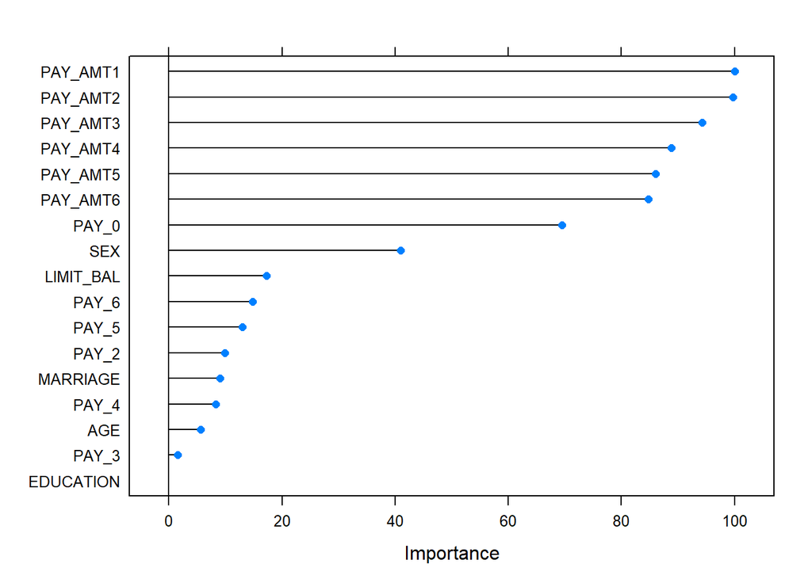

```r
plot(varImp(modelNB))   # returns variable importance
```

Now we do the same modelling but with setting additional argument preProc=c(“center”, “scale”) in order to perform standardization

```r
# Random Forest after scaling

timeStartRFsc <- proc.time()

modelRFsc <- train(DEFAULT_PAYMENT ~., data = train.set, method = "rf", preProc=c("center", "scale"),
               metric = "ROC", type = "Classification", trControl = trainControl)

proc.time() - timeStartRFsc
```

```
##    user  system elapsed
## 1374.09   22.63 1448.70
```

```r
# Print model performance metrics along with other details

print(modelRFsc)    # prints the model information
```

```
## Random Forest
##
## 28000 samples
##    17 predictor
##     2 classes: 'PayInTime', 'Default'
##
## Pre-processing: centered (17), scaled (17)
## Resampling: Cross-Validated (10 fold)
## Summary of sample sizes: 25200, 25200, 25199, 25200, 25200, 25200, ...
## Resampling results across tuning parameters:
##
##   mtry  ROC        Sens       Spec
##    2    0.8946479  0.9052787  0.7400103
##    9    0.8941524  0.9164367  0.7406941
##   17    0.8908616  0.9125743  0.7355615
##
## ROC was used to select the optimal model using the largest value.
## The final value used for the model was mtry = 2.
```

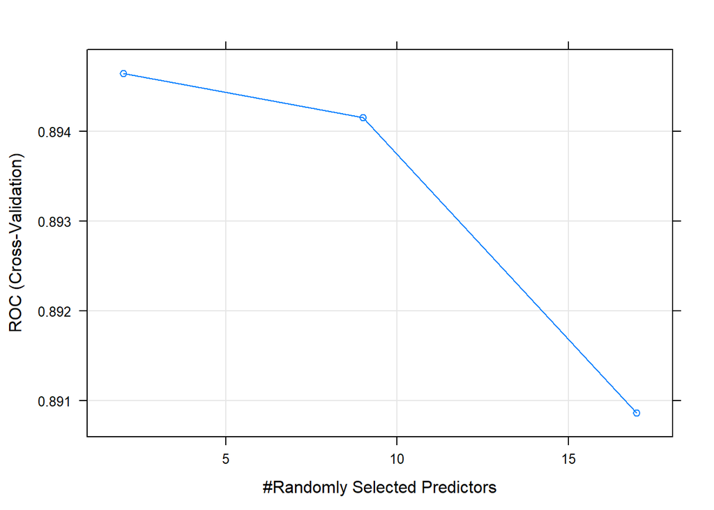

```r
plot(modelRFsc)     # plots the fitted results.
```

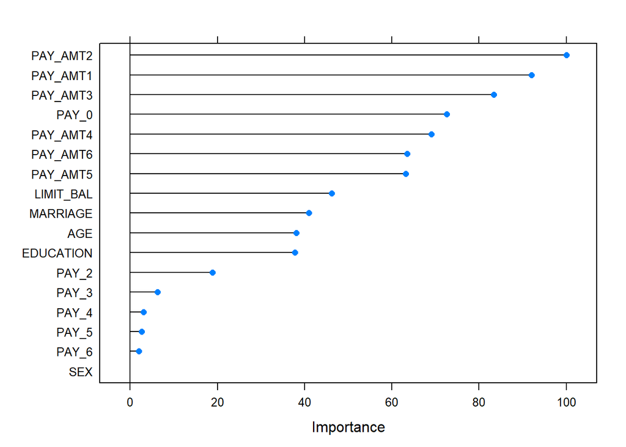

```r
plot(varImp(modelRFsc))   # returns variable importance
```

```r
#Naive Bayes after scaling

timeStartNBsc <- proc.time()

modelNBsc <- train(DEFAULT_PAYMENT ~., data = train.set, method = "nb", preProc=c("center", "scale"),
                 metric = "ROC", type = "Classification", trControl = trainControl)

proc.time() - timeStartNBsc
```

```
##    user  system elapsed
##  131.31    0.23  134.45
```

```r
# Print model performance metrics along with other details

print(modelNBsc)    # prints the model information
```

```
## Naive Bayes
##
## 28000 samples
##    17 predictor
##     2 classes: 'PayInTime', 'Default'
##
## Pre-processing: centered (17), scaled (17)
## Resampling: Cross-Validated (10 fold)
## Summary of sample sizes: 25200, 25200, 25200, 25200, 25200, 25200, ...
## Resampling results across tuning parameters:
##
##   usekernel  ROC        Sens       Spec
##   FALSE      0.7495844  0.2054440  0.9638976
##    TRUE      0.8302176  0.6493817  0.8164932
##
## Tuning parameter 'fL' was held constant at a value of 0
## Tuning
##  parameter 'adjust' was held constant at a value of 1
## ROC was used to select the optimal model using the largest value.
## The final values used for the model were fL = 0, usekernel = TRUE and adjust
##  = 1.
```

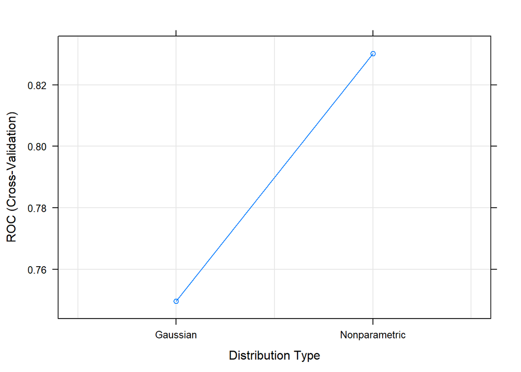

```r
plot(modelNBsc)     # plots the fitted results.
```

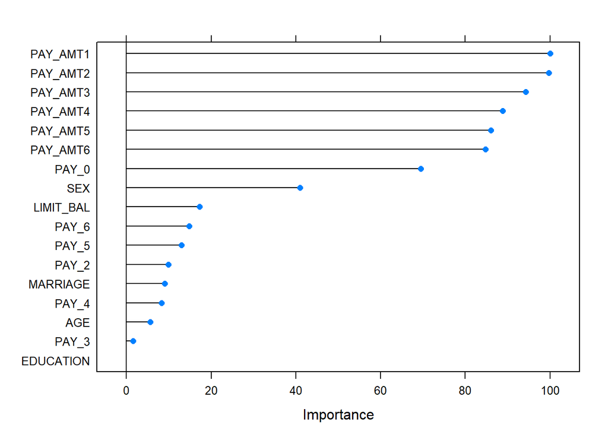

```r
plot(varImp(modelNBsc))   # returns variable importance
```

## Predictions and Conclusions

As long as all models are developed, now we proceed to their validation using a respective part of dataset. After each model returns the outcomes, a confusion matrix is created to get the performance metrics of each classifying algorithm

```r
# Predict using the validation set with Random Forest

defaultPredictionRF <- predict(modelRF, test.set)         # classification outcome required for the confusion matrix # returns classifications

defaultPredRF <- predict(modelRF, test.set, type = "prob")  # predicted data required for ROC curve # returns probabilities

# Create a confusion matrix for the Random forest prediction results

RFmatrix <- confusionMatrix(defaultPredictionRF, test.set$DEFAULT_PAYMENT, mode="prec_recall")
RFmatrix
```

```
## Confusion Matrix and Statistics
##
##            Reference
## Prediction  PayInTime Default
##   PayInTime      6422    1258
##   Default         631    3689
##
##                Accuracy : 0.8426
##                  95% CI : (0.8359, 0.8491)
##     No Information Rate : 0.5878
##     P-Value [Acc > NIR] : < 2.2e-16
##
##                   Kappa : 0.6689
##
##  Mcnemar's Test P-Value : < 2.2e-16
##
##               Precision : 0.8362
##                  Recall : 0.9105
##                      F1 : 0.8718
##              Prevalence : 0.5877
##          Detection Rate : 0.5352
##    Detection Prevalence : 0.6400
##       Balanced Accuracy : 0.8281
##
##        'Positive' Class : PayInTime
##
```

```r
# Predict using the validation set with Naive Bayes

defaultPredictionNB <- predict(modelNB, test.set)           # classification outcome required for the confusion matrix # returns classifications

defaultPredNB <- predict(modelNB, test.set, type = "prob")  # predicted data required for ROC curve # returns probabilities

# Create a confusion matrix for the Naive Bayes prediction results

NBmatrix <- confusionMatrix(defaultPredictionNB, test.set$DEFAULT_PAYMENT, mode="prec_recall")
NBmatrix
```

```
## Confusion Matrix and Statistics
##
##            Reference
## Prediction  PayInTime Default
##   PayInTime      4516     887
##   Default        2537    4060
##
##                Accuracy : 0.7147
##                  95% CI : (0.7065, 0.7227)
##     No Information Rate : 0.5878
##     P-Value [Acc > NIR] : < 2.2e-16
##
##                   Kappa : 0.4391
##
##  Mcnemar's Test P-Value : < 2.2e-16
##
##               Precision : 0.8358
##                  Recall : 0.6403
##                      F1 : 0.7251
##              Prevalence : 0.5877
##          Detection Rate : 0.3763
##    Detection Prevalence : 0.4502
##       Balanced Accuracy : 0.7305
##
##        'Positive' Class : PayInTime
##
```

```r
# Predict using the validation set with Random Forest after scaling

defaultPredictionRFsc <- predict(modelRFsc, test.set)         # classification outcome required for the confusion matrix # returns classifications

defaultPredRFsc <- predict(modelRFsc, test.set, type = "prob")  # predicted data required for ROC curve # returns probabilities


# Create a confusion matrix for the Random Forest after scaling prediction results

scRFmatrix <- confusionMatrix(defaultPredictionRFsc, test.set$DEFAULT_PAYMENT, mode="prec_recall")
scRFmatrix
```

```
## Confusion Matrix and Statistics
##
##            Reference
## Prediction  PayInTime Default
##   PayInTime      6429    1259
##   Default         624    3688
##
##                Accuracy : 0.8431
##                  95% CI : (0.8365, 0.8495)
##     No Information Rate : 0.5878
##     P-Value [Acc > NIR] : < 2.2e-16
##
##                   Kappa : 0.6699
##
##  Mcnemar's Test P-Value : < 2.2e-16
##
##               Precision : 0.8362
##                  Recall : 0.9115
##                      F1 : 0.8723
##              Prevalence : 0.5877
##          Detection Rate : 0.5357
##    Detection Prevalence : 0.6407
##       Balanced Accuracy : 0.8285
##
##        'Positive' Class : PayInTime
##
```

```r
# Predict using the validation set with Naive Bayes after scaling

defaultPredictionNBsc <- predict(modelNBsc, test.set)           # classification outcome required for the confusion matrix # returns classifications

defaultPredNBsc <- predict(modelNBsc, test.set, type = "prob")  # predicted data required for ROC curve # returns probabilities


# Create a confusion matrix for the Naive Bayes after scaling prediction results

scNBmatrix <- confusionMatrix(defaultPredictionNBsc, test.set$DEFAULT_PAYMENT, mode="prec_recall")
scNBmatrix
```

```
## Confusion Matrix and Statistics
##
##            Reference
## Prediction  PayInTime Default
##   PayInTime      4568     891
##   Default        2485    4056
##
##                Accuracy : 0.7187
##                  95% CI : (0.7105, 0.7267)
##     No Information Rate : 0.5878
##     P-Value [Acc > NIR] : < 2.2e-16
##
##                   Kappa : 0.4461
##
##  Mcnemar's Test P-Value : < 2.2e-16
##
##               Precision : 0.8368
##                  Recall : 0.6477
##                      F1 : 0.7302
##              Prevalence : 0.5877
##          Detection Rate : 0.3807
##    Detection Prevalence : 0.4549
##       Balanced Accuracy : 0.7338
##
##        'Positive' Class : PayInTime
##
```

Further we create plots of ROC curves for each method and calculate the area under the curve

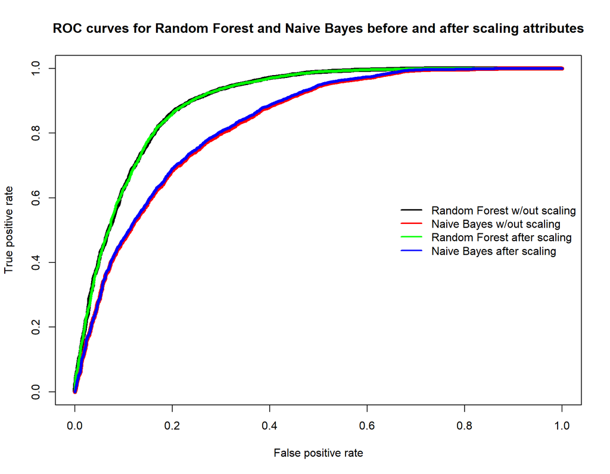

```r
# Random Forest method without scaling

predRF <- prediction(defaultPredRF[,1], test.set$DEFAULT_PAYMENT)

perfRF <- performance(predRF, "tpr", "fpr")

plot(perfRF, main = "ROC curves for Random Forest and Naive Bayes before and after scaling attributes",
     col = 'black', lty = 1, lwd=6)

# Naive Bayes method without scaling

predNB <- prediction(defaultPredNB[,1], test.set$DEFAULT_PAYMENT)

perfNB <- performance(predNB, "tpr", "fpr")

plot(perfNB, add = TRUE, col = "red", lty = 1, lwd=6)


# Random Forest method with scaling

predRFsc <- prediction(defaultPredRFsc[,1], test.set$DEFAULT_PAYMENT)

perfRFsc <- performance(predRFsc, "tpr", "fpr")

plot(perfRFsc, add = TRUE, col = 'green', lty = 1, lwd=4)


# Naive Bayes method with scaling

predNBsc <- prediction(defaultPredNBsc[,1], test.set$DEFAULT_PAYMENT)

perfNBsc <- performance(predNBsc, "tpr", "fpr")

plot(perfNBsc, add = TRUE, col = "blue", lty = 1, lwd=4)

# Add legends to the plot

legend("right", legend = c("Random Forest w/out scaling", "Naive Bayes w/out scaling",
                           "Random Forest after scaling", "Naive Bayes after scaling"),
       bty = "n", cex = 1, lty = 1,
       col = c("black", "red", "green", "blue"), lwd = c(2,2,2,2))
```

```r
# AUC for each method

aucRFtemp<-performance(predRF, "auc")
aucRF<-round(as.numeric(aucRFtemp@y.values),3)
aucRF
```

```
## [1] 0.897
```

```r
aucNBtemp<-performance(predNB, "auc")
aucNB<-round(as.numeric(aucNBtemp@y.values),3)
aucNB
```

```
## [1] 0.829
```

```r
aucRFsctemp<-performance(predRFsc, "auc")
aucRFsc<-round(as.numeric(aucRFsctemp@y.values),3)
aucRFsc
```

```
## [1] 0.897
```

```r
aucNBsctemp<-performance(predNBsc, "auc")
aucNBsc<-round(as.numeric(aucNBsctemp@y.values),3)
aucNBsc
```

```
## [1] 0.832
```

In the end we create a summary table with performance metrics for each developed model in order to compare them and to decide which is the best in our case. For the purpose of comparison of the performance of our models the following parameters from a confusion matrix are going to be used: Accuracy, Precision, Recall, F1 measure and Area under ROC curve (AUC).

```r
mlMethods <- c('Random Forest', 'Naive Bayes', 'Random Forest after scaling', 'Naive Bayes after scaling')

accuracyValue <- c(RFmatrix$overall[[1]], NBmatrix$overall[[1]], scRFmatrix$overall[[1]], scNBmatrix$overall[[1]])

precisionValue <- c(RFmatrix$byClass[[5]], NBmatrix$byClass[[5]], scRFmatrix$byClass[[5]], scNBmatrix$byClass[[5]])

recallValue <- c(RFmatrix$byClass[[6]], NBmatrix$byClass[[6]], scRFmatrix$byClass[[6]], scNBmatrix$byClass[[6]])

F1Value <- c(RFmatrix$byClass[[7]], NBmatrix$byClass[[7]], scRFmatrix$byClass[[7]], scNBmatrix$byClass[[7]])

aucValue <-c(aucRF, aucNB, aucRFsc, aucNBsc)

comparisonTable<-data.frame('ML technique'=mlMethods, 'Accuracy'=accuracyValue,
                            'Precision'=precisionValue, 'Recall'=recallValue, 'F1 Measure'=F1Value,
                            'AUC'=aucValue)

names(comparisonTable) <- gsub("\\.", " ", names(comparisonTable))


comparisonTable<-format(comparisonTable, digits=3)

comparisonTable
```

```
##                  ML technique Accuracy Precision Recall F1 Measure   AUC
## 1               Random Forest    0.843     0.836  0.911      0.872 0.897
## 2                 Naive Bayes    0.715     0.836  0.640      0.725 0.829
## 3 Random Forest after scaling    0.843     0.836  0.912      0.872 0.897
## 4   Naive Bayes after scaling    0.719     0.837  0.648      0.730 0.832
```

Accuracy represents the percentage of correct predictions. It is calculated by dividing the number of correct predictions by the number of total predictions. Precision shows the fraction of relevant examples (true positives) among all of the instances which were predicted to belong to a certain class. And recall demonstrates the percentage of total relevant results correctly classified by the algorithm. ROC graphs show us true positive rates plotted against false positive rates. The value of the area under the curve refers to the ability of the classifier to correctly classify true or false case of an attribute. The closer the area under the curve is to 100% the better the classifier.

In comparison to the results described in [2], where the authors after balancing the dataset with the SMOTE technique got much smaller values of the accuracy, recall, precision and area under ROC curve for the Random Forest classifier (Accuracy – 0.77, Precision – 0.48, Recall – 0.43, AUCROC – 0.65), we can say that the Random Forest models developed in this project are rather accurate and reliable for their practical application.